# portfolio-project-using-python

### Analysis for Average Domestic Itinerary Fare based on Origin City ranked by Passengers in 2021

This project organizes data and visualize the average domestic airfares by US major origin cities. Data is taken from Bureau of US transportation for all the four quarters in 2021. Averages are computed using data from the Bureau of Transportation Statistics' Passenger Origin and Destination (O&D) Survey, a 10% sample of all airline tickets for U.S. carriers

In this project, data was downloaded and prepared for cleaning using python libraries numpy and pandas. Data exploration was done to get the meaningful results and then with the help of matplotlib and seaborn , data visulization of comparing all four quarter's average itinerary prices.

```python
import numpy as np
import pandas as pd
```

```python
!pip install matplotlib seaborn --upgrade --quiet
```

```python
#read excel file
airfareq1_df = pd.read_excel (r'AverageFare_Q1_2021.xlsx')
airfareq2_df = pd.read_excel (r'AverageFare_Q2_2021.xlsx')
airfareq3_df = pd.read_excel (r'AverageFare_Q3_2021.xlsx')
airfareq4_df = pd.read_excel (r'AverageFare_Q4_2021.xlsx')
```

### Data Preparation and Cleaning

In this section, loaded data was checked if there is any missing data, duplicate etc. All the different files were merged and the final data frame was ready for further exploration.

```python
# display the data frame
airfareq1_df
```

|  | PassengerRank | AirportCode | AirportName | CityName | StateName | AverageFare | AdjustedAverageFare | Passengerssample |
| --- | --- | --- | --- | --- | --- | --- | --- | --- |
| 0 | 1 | LAX | Los Angeles International | Los Angeles | CA | 246.229990 | 265.846412 | 981228 |
| 1 | 2 | ORD | Chicago O'Hare International | Chicago-O'Hare | IL | 243.528892 | 262.930125 | 795315 |
| 2 | 3 | ATL | Hartsfield-Jackson Atlanta International | Atlanta | GA | 253.116554 | 273.281608 | 768501 |
| 3 | 4 | DEN | Denver International | Denver | CO | 230.591183 | 248.961707 | 739773 |
| 4 | 5 | EWR | Newark Liberty International | Newark | NJ | 238.211927 | 257.189573 | 652199 |
| ... | ... | ... | ... | ... | ... | ... | ... | ... |
| 417 | 417 | LNY | Lanai Airport | Lanai | HI | 582.625000 | 629.041026 | 13 |
| 418 | 419 | MKT | Mankato Regional | Mankato | MN | 154.500000 | 166.808562 | 9 |
| 419 | 420 | CPX | Benjamin Rivera Noriega | Culebra | PR | 364.000000 | 392.998813 | 7 |
| 420 | 421 | JHM | Kapalua Airport | Kapalua | HI | 484.000000 | 522.558861 | 6 |
| 421 | 422 | SNP | St. Paul Island | St. Paul | AK | 929.000000 | 1003.010707 | 3 |

422 rows × 8 columns

```python
#to know the basic info of data frame
airfareq1_df.info()
```

```
<class 'pandas.core.frame.DataFrame'>
RangeIndex: 422 entries, 0 to 421
Data columns (total 8 columns):
 #   Column               Non-Null Count  Dtype
---  ------               --------------  -----
 0   PassengerRank        422 non-null    int64
 1   AirportCode          422 non-null    object
 2   AirportName          422 non-null    object
 3   CityName             422 non-null    object
 4   StateName            422 non-null    object
 5   AverageFare          422 non-null    float64
 6   AdjustedAverageFare  422 non-null    float64
 7   Passengerssample     422 non-null    int64
dtypes: float64(2), int64(2), object(4)
memory usage: 26.5+ KB
```

```python
#to find a particular record of an airport
airfareq1_df[airfareq1_df.AirportCode =='EWR']
```

|  | PassengerRank | AirportCode | AirportName | CityName | StateName | AverageFare | AdjustedAverageFare | Passengerssample |
| --- | --- | --- | --- | --- | --- | --- | --- | --- |
| 4 | 5 | EWR | Newark Liberty International | Newark | NJ | 238.211927 | 257.189573 | 652199 |

```python
# to find any missing data in whole data frame
for col_name in airfareq1_df.columns:
    permiss = np.mean(airfareq1_df[col_name].isnull())
    print('{}      {}%'.format(col_name,permiss))
```

```
PassengerRank      0.0%
AirportCode      0.0%
AirportName      0.0%
CityName      0.0%
StateName      0.0%
AverageFare       0.0%
 AdjustedAverageFare      0.0%
 Passengerssample      0.0%
```

```python
# to find any duplicates
airfareq1_df.duplicated()
```

```
0      False
1      False
2      False
3      False
4      False
       ...
417    False
418    False
419    False
420    False
421    False
Length: 422, dtype: bool
```

```python
# Round upto 2 decimal places for AverageFare  & AdjustedAvergeFare Column

airfareq1_df['AverageFare'] = np.round(airfareq1_df['AverageFare'],2)
```

```python
airfareq1_df['AdjustedAverageFare'] = np.round(airfareq1_df['AdjustedAverageFare'],2)
```

```python
airfareq1_df
```

|  | PassengerRank | AirportCode | AirportName | CityName | StateName | AverageFare | AdjustedAverageFare | Passengerssample |
| --- | --- | --- | --- | --- | --- | --- | --- | --- |
| 0 | 1 | LAX | Los Angeles International | Los Angeles | CA | 246.23 | 265.85 | 981228 |
| 1 | 2 | ORD | Chicago O'Hare International | Chicago-O'Hare | IL | 243.53 | 262.93 | 795315 |
| 2 | 3 | ATL | Hartsfield-Jackson Atlanta International | Atlanta | GA | 253.12 | 273.28 | 768501 |
| 3 | 4 | DEN | Denver International | Denver | CO | 230.59 | 248.96 | 739773 |
| 4 | 5 | EWR | Newark Liberty International | Newark | NJ | 238.21 | 257.19 | 652199 |
| ... | ... | ... | ... | ... | ... | ... | ... | ... |
| 417 | 417 | LNY | Lanai Airport | Lanai | HI | 582.62 | 629.04 | 13 |
| 418 | 419 | MKT | Mankato Regional | Mankato | MN | 154.50 | 166.81 | 9 |
| 419 | 420 | CPX | Benjamin Rivera Noriega | Culebra | PR | 364.00 | 393.00 | 7 |
| 420 | 421 | JHM | Kapalua Airport | Kapalua | HI | 484.00 | 522.56 | 6 |
| 421 | 422 | SNP | St. Paul Island | St. Paul | AK | 929.00 | 1003.01 | 3 |

422 rows × 8 columns

```python
# to find the average of fares in Quarter 1

print('The Average Fare for Quarter 1  in 2021 : {}'.format(np.mean(airfareq1_df.AverageFare)))
```

```
The Average Fare for Quarter 1  in 2021 : 341.3374407582939
```

```python
# to drop column in data frame
airfareq1_df.drop('PassengerRank', axis = 1, inplace = True)
```

```python
airfareq1_df
```

|  | AirportCode | AirportName | CityName | StateName | AverageFare | AdjustedAverageFare | Passengerssample |
| --- | --- | --- | --- | --- | --- | --- | --- |
| 0 | LAX | Los Angeles International | Los Angeles | CA | 246.23 | 265.85 | 981228 |
| 1 | ORD | Chicago O'Hare International | Chicago-O'Hare | IL | 243.53 | 262.93 | 795315 |
| 2 | ATL | Hartsfield-Jackson Atlanta International | Atlanta | GA | 253.12 | 273.28 | 768501 |
| 3 | DEN | Denver International | Denver | CO | 230.59 | 248.96 | 739773 |
| 4 | EWR | Newark Liberty International | Newark | NJ | 238.21 | 257.19 | 652199 |
| ... | ... | ... | ... | ... | ... | ... | ... |
| 417 | LNY | Lanai Airport | Lanai | HI | 582.62 | 629.04 | 13 |
| 418 | MKT | Mankato Regional | Mankato | MN | 154.50 | 166.81 | 9 |
| 419 | CPX | Benjamin Rivera Noriega | Culebra | PR | 364.00 | 393.00 | 7 |
| 420 | JHM | Kapalua Airport | Kapalua | HI | 484.00 | 522.56 | 6 |
| 421 | SNP | St. Paul Island | St. Paul | AK | 929.00 | 1003.01 | 3 |

422 rows × 7 columns

```python
airfareq2_df.drop('PassengerRank', axis = 1, inplace = True)
```

```python
airfareq2_df
```

|  | AirportCode | AirportName | CityName | StateName | AverageFare | AdjustedAverageFare | Passengerssample |
| --- | --- | --- | --- | --- | --- | --- | --- |
| 0 | LAX | Los Angeles International | Los Angeles | CA | 314.671669 | 331.973168 | 981228 |
| 1 | ORD | Chicago O'Hare International | Chicago-O'Hare | IL | 272.571215 | 287.557918 | 795315 |
| 2 | ATL | Hartsfield-Jackson Atlanta International | Atlanta | GA | 295.725064 | 311.984827 | 768501 |
| 3 | DEN | Denver International | Denver | CO | 265.674846 | 280.282367 | 739773 |
| 4 | EWR | Newark Liberty International | Newark | NJ | 301.780450 | 318.373155 | 652199 |
| ... | ... | ... | ... | ... | ... | ... | ... |
| 430 | MCN | Middle Georgia Regional | Macon | GA | 390.000000 | 411.443254 | 6 |
| 431 | JHM | Kapalua Airport | Kapalua | HI | 483.500000 | 510.084137 | 6 |
| 432 | SNP | St. Paul Island | St. Paul | AK | 1316.000000 | 1388.357237 | 3 |
| 433 | CEC | Jack McNamara Field | Crescent City | CA | 328.000000 | 346.034327 | 1 |
| 434 | OLF | L. M. Clayton | Wolf Point | MT | 770.000000 | 812.336681 | 1 |

435 rows × 7 columns

```python
# Merge files for Quarter 2, 3 and 4
mergedairfare_df = airfareq1_df.merge(airfareq2_df,  on =['AirportCode','AirportName','CityName','StateName','Passengerssample'])
```

```python
mergedairfare_df
```

|  | AirportCode | AirportName | CityName | StateName | AverageFare_x | AdjustedAverageFare_x | Passengerssample | AverageFare_y | AdjustedAverageFare_y |
| --- | --- | --- | --- | --- | --- | --- | --- | --- | --- |
| 0 | LAX | Los Angeles International | Los Angeles | CA | 246.23 | 265.85 | 981228 | 314.671669 | 331.973168 |
| 1 | ORD | Chicago O'Hare International | Chicago-O'Hare | IL | 243.53 | 262.93 | 795315 | 272.571215 | 287.557918 |
| 2 | ATL | Hartsfield-Jackson Atlanta International | Atlanta | GA | 253.12 | 273.28 | 768501 | 295.725064 | 311.984827 |
| 3 | DEN | Denver International | Denver | CO | 230.59 | 248.96 | 739773 | 265.674846 | 280.282367 |
| 4 | EWR | Newark Liberty International | Newark | NJ | 238.21 | 257.19 | 652199 | 301.780450 | 318.373155 |
| ... | ... | ... | ... | ... | ... | ... | ... | ... | ... |
| 417 | LNY | Lanai Airport | Lanai | HI | 582.62 | 629.04 | 13 | 496.000000 | 523.271421 |
| 418 | MKT | Mankato Regional | Mankato | MN | 154.50 | 166.81 | 9 | 261.000000 | 275.350485 |
| 419 | CPX | Benjamin Rivera Noriega | Culebra | PR | 364.00 | 393.00 | 7 | 520.250000 | 548.854751 |
| 420 | JHM | Kapalua Airport | Kapalua | HI | 484.00 | 522.56 | 6 | 483.500000 | 510.084137 |
| 421 | SNP | St. Paul Island | St. Paul | AK | 929.00 | 1003.01 | 3 | 1316.000000 | 1388.357237 |

422 rows × 9 columns

```python
mergedairfare_df.rename({'AverageFare_x' : 'AverageFare_Q1' ,'AdjustedAverageFare_x' : 'AdjustedAverageFare_Q1', 'AverageFare_y' : 'AverageFare_Q2' ,'AdjustedAverageFare_y' : 'AdjustedAverageFare_Q2'},axis = 1, inplace = True)
```

```python
mergedairfare_df
```

|  | AirportCode | AirportName | CityName | StateName | AverageFare_Q1 | AdjustedAverageFare_Q1 | Passengerssample | AverageFare_Q2 | AdjustedAverageFare_Q2 |
| --- | --- | --- | --- | --- | --- | --- | --- | --- | --- |
| 0 | LAX | Los Angeles International | Los Angeles | CA | 246.23 | 265.85 | 981228 | 314.671669 | 331.973168 |
| 1 | ORD | Chicago O'Hare International | Chicago-O'Hare | IL | 243.53 | 262.93 | 795315 | 272.571215 | 287.557918 |
| 2 | ATL | Hartsfield-Jackson Atlanta International | Atlanta | GA | 253.12 | 273.28 | 768501 | 295.725064 | 311.984827 |
| 3 | DEN | Denver International | Denver | CO | 230.59 | 248.96 | 739773 | 265.674846 | 280.282367 |
| 4 | EWR | Newark Liberty International | Newark | NJ | 238.21 | 257.19 | 652199 | 301.780450 | 318.373155 |
| ... | ... | ... | ... | ... | ... | ... | ... | ... | ... |
| 417 | LNY | Lanai Airport | Lanai | HI | 582.62 | 629.04 | 13 | 496.000000 | 523.271421 |
| 418 | MKT | Mankato Regional | Mankato | MN | 154.50 | 166.81 | 9 | 261.000000 | 275.350485 |
| 419 | CPX | Benjamin Rivera Noriega | Culebra | PR | 364.00 | 393.00 | 7 | 520.250000 | 548.854751 |
| 420 | JHM | Kapalua Airport | Kapalua | HI | 484.00 | 522.56 | 6 | 483.500000 | 510.084137 |
| 421 | SNP | St. Paul Island | St. Paul | AK | 929.00 | 1003.01 | 3 | 1316.000000 | 1388.357237 |

422 rows × 9 columns

```python
airfareq3_df.drop('PassengerRank', axis = 1, inplace = True)
```

```python
mergedairfare1_df = mergedairfare_df.merge(airfareq3_df,  on =['AirportCode','AirportName','CityName','StateName','Passengerssample'])
```

```python
mergedairfare1_df.rename({'AverageFare' : 'AverageFare_Q3' ,'AdjustedAverageFare' : 'AdjustedAverageFare_Q3'},axis = 1, inplace = True)
```

```python
mergedairfare1_df
```

|  | AirportCode | AirportName | CityName | StateName | AverageFare_Q1 | AdjustedAverageFare_Q1 | Passengerssample | AverageFare_Q2 | AdjustedAverageFare_Q2 | AverageFare_Q3 | AdjustedAverageFare_Q3 |
| --- | --- | --- | --- | --- | --- | --- | --- | --- | --- | --- | --- |
| 0 | LAX | Los Angeles International | Los Angeles | CA | 246.23 | 265.85 | 981228 | 314.671669 | 331.973168 | 330.611006 | 343.292858 |
| 1 | ORD | Chicago O'Hare International | Chicago-O'Hare | IL | 243.53 | 262.93 | 795315 | 272.571215 | 287.557918 | 290.439610 | 301.580534 |
| 2 | ATL | Hartsfield-Jackson Atlanta International | Atlanta | GA | 253.12 | 273.28 | 768501 | 295.725064 | 311.984827 | 310.732080 | 322.651401 |
| 3 | DEN | Denver International | Denver | CO | 230.59 | 248.96 | 739773 | 265.674846 | 280.282367 | 269.195854 | 279.521893 |
| 4 | EWR | Newark Liberty International | Newark | NJ | 238.21 | 257.19 | 652199 | 301.780450 | 318.373155 | 341.813586 | 354.925157 |
| ... | ... | ... | ... | ... | ... | ... | ... | ... | ... | ... | ... |
| 416 | GGW | Wokal Field Glasgow Valley County | Glasgow | MT | 461.00 | 497.73 | 13 | 637.000000 | 672.023982 | 469.500000 | 487.509473 |
| 417 | LNY | Lanai Airport | Lanai | HI | 582.62 | 629.04 | 13 | 496.000000 | 523.271421 | 1536.000000 | 1594.919170 |
| 418 | MKT | Mankato Regional | Mankato | MN | 154.50 | 166.81 | 9 | 261.000000 | 275.350485 | 307.000000 | 318.776162 |
| 419 | JHM | Kapalua Airport | Kapalua | HI | 484.00 | 522.56 | 6 | 483.500000 | 510.084137 | 1132.000000 | 1175.422201 |
| 420 | SNP | St. Paul Island | St. Paul | AK | 929.00 | 1003.01 | 3 | 1316.000000 | 1388.357237 | 1599.000000 | 1660.335776 |

421 rows × 11 columns

```python
combined_df = mergedairfare1_df.merge(airfareq4_df,  on =['AirportCode','AirportName','CityName','StateName','Passengerssample'])
```

```python
combined_df.rename({'AverageFare' : 'AverageFare_Q4' ,'AdjustedAverageFare' : 'AdjustedAverageFare_Q4'},axis = 1, inplace = True)
```

```python
# combined data frame with all the 4 quarters
combined_df['AverageFare_Q1'] = np.round(combined_df['AverageFare_Q1'],2)
combined_df['AverageFare_Q2'] = np.round(combined_df['AverageFare_Q2'],2)
combined_df['AverageFare_Q3'] = np.round(combined_df['AverageFare_Q3'],2)
combined_df['AverageFare_Q4'] = np.round(combined_df['AverageFare_Q4'],2)
combined_df['AdjustedAverageFare_Q1'] = np.round(combined_df['AdjustedAverageFare_Q1'],2)
combined_df['AdjustedAverageFare_Q2'] = np.round(combined_df['AdjustedAverageFare_Q2'],2)
combined_df['AdjustedAverageFare_Q3'] = np.round(combined_df['AdjustedAverageFare_Q3'],2)
combined_df['AdjustedAverageFare_Q4'] = np.round(combined_df['AdjustedAverageFare_Q4'],2)
```

```python
combined_df
```

|  | AirportCode | AirportName | CityName | StateName | AverageFare_Q1 | AdjustedAverageFare_Q1 | Passengerssample | AverageFare_Q2 | AdjustedAverageFare_Q2 | AverageFare_Q3 | AdjustedAverageFare_Q3 | PassengerRank | AverageFare_Q4 | AdjustedAverageFare_Q4 |
| --- | --- | --- | --- | --- | --- | --- | --- | --- | --- | --- | --- | --- | --- | --- |
| 0 | LAX | Los Angeles International | Los Angeles | CA | 246.23 | 265.85 | 981228 | 314.67 | 331.97 | 330.61 | 343.29 | 1 | 350.25 | 358.24 |
| 1 | ORD | Chicago O'Hare International | Chicago-O'Hare | IL | 243.53 | 262.93 | 795315 | 272.57 | 287.56 | 290.44 | 301.58 | 2 | 309.70 | 316.78 |
| 2 | ATL | Hartsfield-Jackson Atlanta International | Atlanta | GA | 253.12 | 273.28 | 768501 | 295.73 | 311.98 | 310.73 | 322.65 | 3 | 327.99 | 335.47 |
| 3 | DEN | Denver International | Denver | CO | 230.59 | 248.96 | 739773 | 265.67 | 280.28 | 269.20 | 279.52 | 4 | 295.80 | 302.56 |
| 4 | EWR | Newark Liberty International | Newark | NJ | 238.21 | 257.19 | 652199 | 301.78 | 318.37 | 341.81 | 354.93 | 5 | 331.69 | 339.26 |
| ... | ... | ... | ... | ... | ... | ... | ... | ... | ... | ... | ... | ... | ... | ... |
| 414 | HVR | Havre City-County | Havre | MT | 266.62 | 287.87 | 16 | 339.67 | 358.34 | 445.00 | 462.07 | 423 | 531.25 | 543.38 |
| 415 | GGW | Wokal Field Glasgow Valley County | Glasgow | MT | 461.00 | 497.73 | 13 | 637.00 | 672.02 | 469.50 | 487.51 | 425 | 443.71 | 453.85 |
| 416 | LNY | Lanai Airport | Lanai | HI | 582.62 | 629.04 | 13 | 496.00 | 523.27 | 1536.00 | 1594.92 | 425 | 778.00 | 795.77 |
| 417 | MKT | Mankato Regional | Mankato | MN | 154.50 | 166.81 | 9 | 261.00 | 275.35 | 307.00 | 318.78 | 429 | 247.50 | 253.15 |
| 418 | JHM | Kapalua Airport | Kapalua | HI | 484.00 | 522.56 | 6 | 483.50 | 510.08 | 1132.00 | 1175.42 | 431 | 418.50 | 428.06 |

419 rows × 14 columns

### Exploratory Analysis and Visualization

With all the individual 4 data frames for each quarter and one combined data frame which include all the information plus all the average prices and adjustment prices for all quarters.

```python
import seaborn as sns
import matplotlib
import matplotlib.pyplot as plt
%matplotlib inline

sns.set_style('darkgrid')
matplotlib.rcParams['font.size'] = 14
matplotlib.rcParams['figure.figsize'] = (9, 5)
matplotlib.rcParams['figure.facecolor'] = '#00000000'
```

```python
# Which Quarter has the  highest average in 2021?

Av_df = combined_df[['AverageFare_Q1','AverageFare_Q2','AverageFare_Q3','AverageFare_Q4']].mean().max()

print('        {}  {}  {}  {} and the Quarter with max average fare is {}'.format(combined_df[['AverageFare_Q1']].mean(),combined_df[['AverageFare_Q2']].mean(),combined_df[['AverageFare_Q3']].mean(),combined_df[['AverageFare_Q4']].mean(),Av_df))
```

```
        AverageFare_Q1    339.951146
dtype: float64  AverageFare_Q2    371.055513
dtype: float64  AverageFare_Q3    386.726492
dtype: float64  AverageFare_Q4    398.883246
dtype: float64 and the Quarter with max average fare is 398.8832458233892
```

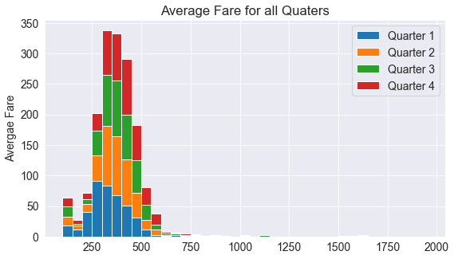

```python
# A histogram plot explains the comparsion of Average airfare for all 4 quarter's

plt.title('Average Fare for all Quaters')
plt.ylabel('Avergae Fare')
plt.hist([combined_df.AverageFare_Q1,combined_df.AverageFare_Q2,combined_df.AverageFare_Q3,combined_df.AverageFare_Q4], bins=np.arange(100,2000,50), stacked= True)

plt.legend(['Quarter 1','Quarter 2','Quarter 3','Quarter 4'])
```

The histogram explains that quarter 4 has the highest average fare.

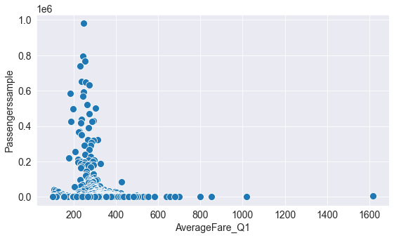

```python
#Scatterplot diagram shows average fare for quarter 1 and passenger's 10% survey sample
sns.scatterplot(x = 'AverageFare_Q1', y = 'Passengerssample',sizes=(200,100), hue_norm=(0, 7), legend="full",s = 100, data = combined_df)
```

```
 [Text(0.8316101427436979, 0.7200170626351895, 'Quarter 1'),
 [Text(0.4536055324056534, 0.3927365796191942, '23%'),
```

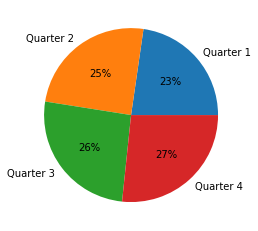

```python
# A pie chart of all the 4 quarters
data = [combined_df.AverageFare_Q1.mean(),combined_df.AverageFare_Q2.mean(),combined_df.AverageFare_Q3.mean(),combined_df.AverageFare_Q4.mean()]
keys = ['Quarter 1','Quarter 2', 'Quarter 3','Quarter 4']

plt.pie(data,labels = keys,autopct= '%.0f%%')
```

Pie chart explains that quarter 4 has highest average fare of 27%

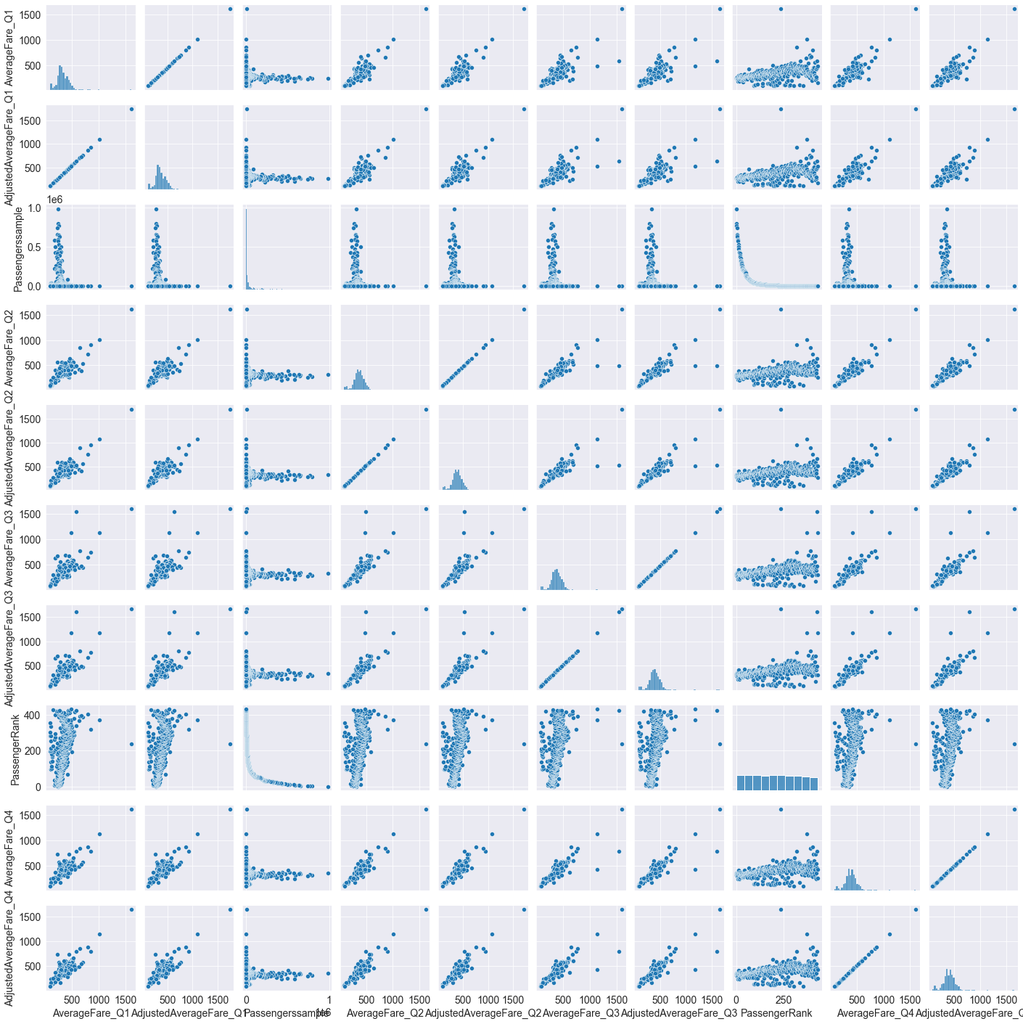

```python
# Seaborn's pairplot which gives us a variety of graphs with different comparsions of columns with a data frame.
sns.pairplot(combined_df, height = 2)
```

```python
combined_df
```

|  | AirportCode | AirportName | CityName | StateName | AverageFare_Q1 | AdjustedAverageFare_Q1 | Passengerssample | AverageFare_Q2 | AdjustedAverageFare_Q2 | AverageFare_Q3 | AdjustedAverageFare_Q3 | PassengerRank | AverageFare_Q4 | AdjustedAverageFare_Q4 |
| --- | --- | --- | --- | --- | --- | --- | --- | --- | --- | --- | --- | --- | --- | --- |
| 0 | LAX | Los Angeles International | Los Angeles | CA | 246.23 | 265.85 | 981228 | 314.67 | 331.97 | 330.61 | 343.29 | 1 | 350.25 | 358.24 |
| 1 | ORD | Chicago O'Hare International | Chicago-O'Hare | IL | 243.53 | 262.93 | 795315 | 272.57 | 287.56 | 290.44 | 301.58 | 2 | 309.70 | 316.78 |
| 2 | ATL | Hartsfield-Jackson Atlanta International | Atlanta | GA | 253.12 | 273.28 | 768501 | 295.73 | 311.98 | 310.73 | 322.65 | 3 | 327.99 | 335.47 |
| 3 | DEN | Denver International | Denver | CO | 230.59 | 248.96 | 739773 | 265.67 | 280.28 | 269.20 | 279.52 | 4 | 295.80 | 302.56 |
| 4 | EWR | Newark Liberty International | Newark | NJ | 238.21 | 257.19 | 652199 | 301.78 | 318.37 | 341.81 | 354.93 | 5 | 331.69 | 339.26 |
| ... | ... | ... | ... | ... | ... | ... | ... | ... | ... | ... | ... | ... | ... | ... |
| 414 | HVR | Havre City-County | Havre | MT | 266.62 | 287.87 | 16 | 339.67 | 358.34 | 445.00 | 462.07 | 423 | 531.25 | 543.38 |
| 415 | GGW | Wokal Field Glasgow Valley County | Glasgow | MT | 461.00 | 497.73 | 13 | 637.00 | 672.02 | 469.50 | 487.51 | 425 | 443.71 | 453.85 |
| 416 | LNY | Lanai Airport | Lanai | HI | 582.62 | 629.04 | 13 | 496.00 | 523.27 | 1536.00 | 1594.92 | 425 | 778.00 | 795.77 |
| 417 | MKT | Mankato Regional | Mankato | MN | 154.50 | 166.81 | 9 | 261.00 | 275.35 | 307.00 | 318.78 | 429 | 247.50 | 253.15 |
| 418 | JHM | Kapalua Airport | Kapalua | HI | 484.00 | 522.56 | 6 | 483.50 | 510.08 | 1132.00 | 1175.42 | 431 | 418.50 | 428.06 |

419 rows × 14 columns

```python
# Data frame of Statewise Adjustment fares

Statewise_df = combined_df.groupby('StateName')[['AdjustedAverageFare_Q1', 'AdjustedAverageFare_Q2', 'AdjustedAverageFare_Q3','AdjustedAverageFare_Q4']].mean()
```

```python
Statewise_df
```

| StateName | AdjustedAverageFare_Q1 | AdjustedAverageFare_Q2 | AdjustedAverageFare_Q3 | AdjustedAverageFare_Q4 |
| --- | --- | --- | --- | --- |
| AK | 573.659545 | 522.545455 | 521.077273 | 552.682273 |
| AL | 444.678333 | 453.268333 | 470.821667 | 464.203333 |
| AR | 362.325714 | 428.555714 | 422.980000 | 391.405714 |
| AZ | 316.660000 | 396.027500 | 389.907500 | 400.565000 |
| CA | 303.650435 | 348.546957 | 341.430870 | 340.229565 |
| CO | 392.640000 | 427.062500 | 445.348333 | 459.018333 |
| CT | 293.185000 | 325.435000 | 340.695000 | 261.845000 |
| DC | 328.435000 | 376.520000 | 389.150000 | 377.040000 |
| DE | 106.860000 | 105.140000 | 97.260000 | 88.250000 |
| FL | 271.742105 | 286.444211 | 287.063158 | 306.325789 |
| GA | 404.881429 | 428.504286 | 431.535714 | 443.271429 |
| HI | 341.708750 | 380.183750 | 607.208750 | 412.445000 |
| IA | 356.732857 | 364.902857 | 383.384286 | 390.720000 |
| ID | 420.426667 | 454.950000 | 465.116667 | 475.455000 |
| IL | 291.263333 | 320.251667 | 314.736667 | 332.813333 |
| IN | 310.380000 | 356.502500 | 358.210000 | 372.405000 |
| KS | 422.342857 | 383.828571 | 392.435714 | 408.024286 |
| KY | 355.730000 | 333.515000 | 334.752500 | 346.532500 |
| LA | 396.491429 | 426.632857 | 437.308571 | 438.017143 |
| MA | 415.012000 | 371.600000 | 393.282000 | 395.692000 |
| MD | 253.370000 | 283.366667 | 290.626667 | 316.470000 |
| ME | 344.403333 | 413.430000 | 427.263333 | 457.446667 |
| MI | 412.639412 | 429.632353 | 442.035294 | 443.724706 |
| MN | 380.730000 | 408.619000 | 412.405000 | 421.411000 |
| MO | 357.891250 | 384.487500 | 383.955000 | 393.303750 |
| MS | 441.887143 | 415.387143 | 419.167143 | 434.904286 |
| MT | 374.094000 | 430.233000 | 428.813000 | 480.077000 |
| NC | 311.008000 | 335.797000 | 348.295000 | 367.661000 |
| ND | 411.957500 | 463.896250 | 466.168750 | 479.986250 |
| NE | 379.101111 | 435.282222 | 434.305556 | 422.435556 |
| NH | 264.533333 | 319.016667 | 328.076667 | 354.153333 |
| NJ | 169.223333 | 182.423333 | 191.550000 | 200.470000 |
| NM | 393.510000 | 431.161667 | 417.703333 | 462.316667 |
| NV | 357.826667 | 384.026667 | 393.846667 | 418.030000 |
| NY | 285.108889 | 343.770000 | 369.995000 | 348.615000 |
| OH | 263.528571 | 285.751429 | 287.841429 | 289.927143 |
| OK | 359.925000 | 389.585000 | 374.890000 | 395.612500 |
| OR | 328.620000 | 386.228333 | 394.510000 | 407.050000 |
| PA | 347.233846 | 348.442308 | 360.701538 | 345.859231 |
| PR | 334.316667 | 439.700000 | 445.013333 | 513.833333 |
| RI | 260.730000 | 334.720000 | 354.360000 | 355.260000 |
| SC | 337.238333 | 337.906667 | 324.823333 | 349.565000 |
| SD | 422.976000 | 443.762000 | 436.832000 | 456.510000 |
| TN | 331.072000 | 371.582000 | 384.898000 | 390.094000 |
| TT | 1333.605000 | 1330.845000 | 1211.545000 | 1217.620000 |
| TX | 351.303846 | 395.888462 | 405.366923 | 404.500000 |
| UT | 320.062857 | 314.232857 | 321.270000 | 341.075714 |
| VA | 366.477143 | 413.647143 | 423.154286 | 430.315714 |
| VI | 311.105000 | 325.505000 | 325.050000 | 357.615000 |
| VT | 349.885000 | 387.260000 | 476.455000 | 431.235000 |
| WA | 297.792222 | 343.496667 | 359.801111 | 392.978889 |
| WI | 388.020000 | 407.585000 | 407.022500 | 421.958750 |
| WV | 380.734286 | 361.582857 | 390.950000 | 396.157143 |
| WY | 492.116667 | 459.744444 | 475.556667 | 517.622222 |

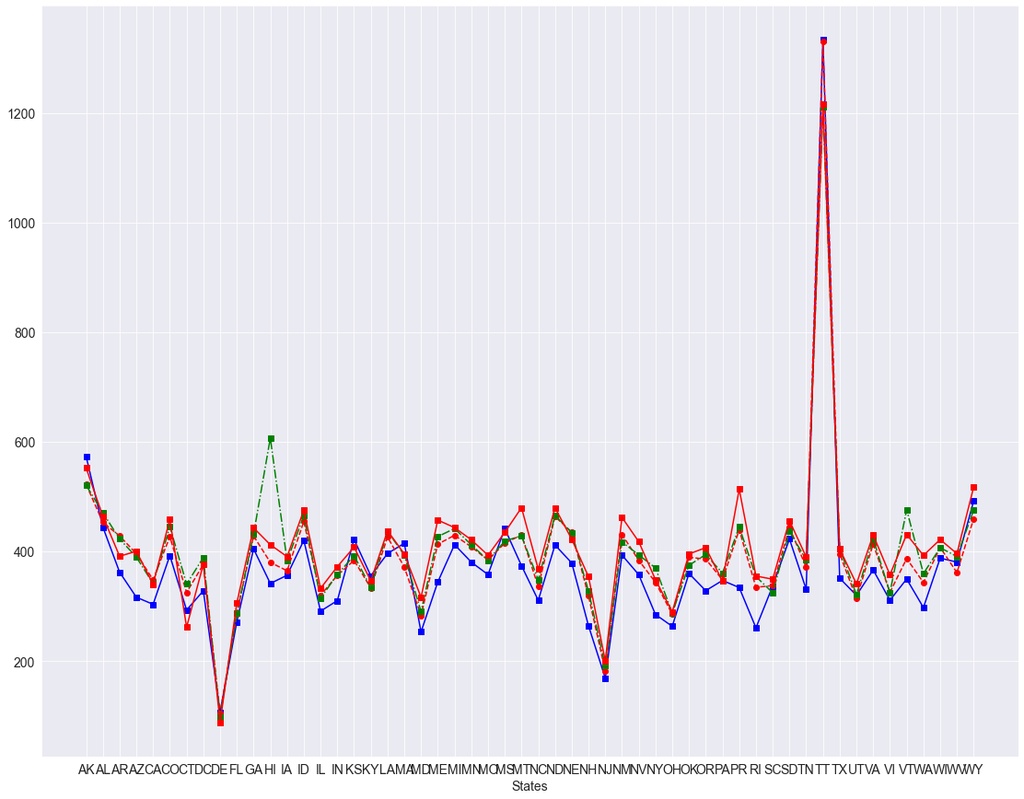

```python
# A line graph showing statewise adjusted fares by airlines
plt.figure(figsize=(19,15))
plt.xlabel('States')

plt.plot( Statewise_df.AdjustedAverageFare_Q1, 's-b')
plt.plot( Statewise_df.AdjustedAverageFare_Q2, 'o--r')
plt.plot( Statewise_df.AdjustedAverageFare_Q3, 's-.g')
plt.plot( Statewise_df.AdjustedAverageFare_Q4, 'r-s')
```

### Asking and Answering Questions

Some interesting data explorations which were performed on different data frames.

```python
 # What are the top 5 airports for  the best average fares for quarter 1 ?

combined_df.sort_values(by ='AverageFare_Q1', ascending = True).head(5)
```

[output not shown]

```python
# Which State has max airports ?
airports_count = airfareq1_df.groupby('StateName')['StateName'].count().sort_values(ascending = False).head(1)

airports_count.sort_values(ascending = False).head(1)
```

```
StateName
TX    26
Name: StateName, dtype: int64
```

```python
# How to add a new column in data frame to get combined average fare for each airport for all 4 quarters ?

combined_df['CombinedAverageFare'] = combined_df.AverageFare_Q1 + combined_df.AverageFare_Q2 + combined_df.AverageFare_Q3 + combined_df.AverageFare_Q4
combined_df
```

|  | AirportCode | AirportName | CityName | StateName | AverageFare_Q1 | AdjustedAverageFare_Q1 | Passengerssample | AverageFare_Q2 | AdjustedAverageFare_Q2 | AverageFare_Q3 | AdjustedAverageFare_Q3 | PassengerRank | AverageFare_Q4 | AdjustedAverageFare_Q4 | CombinedAverageFare |
| --- | --- | --- | --- | --- | --- | --- | --- | --- | --- | --- | --- | --- | --- | --- | --- |
| 0 | LAX | Los Angeles International | Los Angeles | CA | 246.23 | 265.85 | 981228 | 314.67 | 331.97 | 330.61 | 343.29 | 1 | 350.25 | 358.24 | 1241.76 |
| 1 | ORD | Chicago O'Hare International | Chicago-O'Hare | IL | 243.53 | 262.93 | 795315 | 272.57 | 287.56 | 290.44 | 301.58 | 2 | 309.70 | 316.78 | 1116.24 |
| 2 | ATL | Hartsfield-Jackson Atlanta International | Atlanta | GA | 253.12 | 273.28 | 768501 | 295.73 | 311.98 | 310.73 | 322.65 | 3 | 327.99 | 335.47 | 1187.57 |
| 3 | DEN | Denver International | Denver | CO | 230.59 | 248.96 | 739773 | 265.67 | 280.28 | 269.20 | 279.52 | 4 | 295.80 | 302.56 | 1061.26 |
| 4 | EWR | Newark Liberty International | Newark | NJ | 238.21 | 257.19 | 652199 | 301.78 | 318.37 | 341.81 | 354.93 | 5 | 331.69 | 339.26 | 1213.49 |
| ... | ... | ... | ... | ... | ... | ... | ... | ... | ... | ... | ... | ... | ... | ... | ... |
| 414 | HVR | Havre City-County | Havre | MT | 266.62 | 287.87 | 16 | 339.67 | 358.34 | 445.00 | 462.07 | 423 | 531.25 | 543.38 | 1582.54 |
| 415 | GGW | Wokal Field Glasgow Valley County | Glasgow | MT | 461.00 | 497.73 | 13 | 637.00 | 672.02 | 469.50 | 487.51 | 425 | 443.71 | 453.85 | 2011.21 |
| 416 | LNY | Lanai Airport | Lanai | HI | 582.62 | 629.04 | 13 | 496.00 | 523.27 | 1536.00 | 1594.92 | 425 | 778.00 | 795.77 | 3392.62 |
| 417 | MKT | Mankato Regional | Mankato | MN | 154.50 | 166.81 | 9 | 261.00 | 275.35 | 307.00 | 318.78 | 429 | 247.50 | 253.15 | 970.00 |
| 418 | JHM | Kapalua Airport | Kapalua | HI | 484.00 | 522.56 | 6 | 483.50 | 510.08 | 1132.00 | 1175.42 | 431 | 418.50 | 428.06 | 2518.00 |

419 rows × 15 columns

```python
# Which airport has cheap fare from  all 4 quarters ?
combined_df.sort_values(by= 'CombinedAverageFare', ascending = True ).head(1)
```

|  | AirportCode | AirportName | CityName | StateName | AverageFare_Q1 | AdjustedAverageFare_Q1 | Passengerssample | AverageFare_Q2 | AdjustedAverageFare_Q2 | AverageFare_Q3 | AdjustedAverageFare_Q3 | PassengerRank | AverageFare_Q4 | AdjustedAverageFare_Q4 | CombinedAverageFare |
| --- | --- | --- | --- | --- | --- | --- | --- | --- | --- | --- | --- | --- | --- | --- | --- |
| 300 | OGD | Ogden-Hinckley | Ogden | UT | 100.06 | 108.03 | 1229 | 91.36 | 96.38 | 80.08 | 83.15 | 303 | 96.28 | 98.48 | 367.78 |

```python
# How to  find correlation between columns ?
combined_df.corr(method='pearson')
```

|  | AverageFare_Q1 | AdjustedAverageFare_Q1 | Passengerssample | AverageFare_Q2 | AdjustedAverageFare_Q2 | AverageFare_Q3 | AdjustedAverageFare_Q3 | PassengerRank | AverageFare_Q4 | AdjustedAverageFare_Q4 | CombinedAverageFare |
| --- | --- | --- | --- | --- | --- | --- | --- | --- | --- | --- | --- |
| AverageFare_Q1 | 1.000000 | 1.000000 | -0.265796 | 0.893685 | 0.893685 | 0.805195 | 0.805194 | 0.409879 | 0.870689 | 0.870690 | 0.934218 |
| AdjustedAverageFare_Q1 | 1.000000 | 1.000000 | -0.265796 | 0.893686 | 0.893686 | 0.805196 | 0.805196 | 0.409880 | 0.870690 | 0.870691 | 0.934219 |
| Passengerssample | -0.265796 | -0.265796 | 1.000000 | -0.244614 | -0.244616 | -0.218215 | -0.218216 | -0.602113 | -0.235005 | -0.235006 | -0.252198 |
| AverageFare_Q2 | 0.893685 | 0.893686 | -0.244614 | 1.000000 | 1.000000 | 0.873281 | 0.873281 | 0.392735 | 0.930975 | 0.930974 | 0.968703 |
| AdjustedAverageFare_Q2 | 0.893685 | 0.893686 | -0.244616 | 1.000000 | 1.000000 | 0.873280 | 0.873279 | 0.392736 | 0.930974 | 0.930974 | 0.968703 |
| AverageFare_Q3 | 0.805195 | 0.805196 | -0.218215 | 0.873281 | 0.873280 | 1.000000 | 1.000000 | 0.405125 | 0.886000 | 0.886001 | 0.939644 |
| AdjustedAverageFare_Q3 | 0.805194 | 0.805196 | -0.218216 | 0.873281 | 0.873279 | 1.000000 | 1.000000 | 0.405126 | 0.886000 | 0.886000 | 0.939644 |
| PassengerRank | 0.409879 | 0.409880 | -0.602113 | 0.392735 | 0.392736 | 0.405125 | 0.405126 | 1.000000 | 0.391109 | 0.391109 | 0.419987 |
| AverageFare_Q4 | 0.870689 | 0.870690 | -0.235005 | 0.930975 | 0.930974 | 0.886000 | 0.886000 | 0.391109 | 1.000000 | 1.000000 | 0.967606 |
| AdjustedAverageFare_Q4 | 0.870690 | 0.870691 | -0.235006 | 0.930974 | 0.930974 | 0.886001 | 0.886000 | 0.391109 | 1.000000 | 1.000000 | 0.967606 |
| CombinedAverageFare | 0.934218 | 0.934219 | -0.252198 | 0.968703 | 0.968703 | 0.939644 | 0.939644 | 0.419987 | 0.967606 | 0.967606 | 1.000000 |

### Inferences and Conclusion

Based on the passengers survey sample, we came to conculsion that during quarter 4, the fares are little high than rest of the year.

Texas is the state which has maximum airports in US

Ogden-Hinckley airport in Utah has the cheapest average fare for all quarters.

### References and Future Work

Check out the following resources to learn more about the dataset and tools used in this notebook:

Pandas user guide: https://pandas.pydata.org/docs/user_guide/index.html Matplotlib user guide: https://matplotlib.org/3.3.1/users/index.html Seaborn user guide & tutorial: https://seaborn.pydata.org/tutorial.html

For future predictions, I can extend this project by adding other discounts offered by airlines to passengers.Mileage plus airfares can also be included.